# jekyll-jupyter-notebook20261007-3382-869f1h

```python
# Install necessary libraries if not already present in Colab environment
!pip install numpy tensorflow matplotlib scikit-learn
```

```python
# Import libraries
import numpy as np
import matplotlib.pyplot as plt
import seaborn as sns

# TensorFlow and Keras
import tensorflow as tf
from tensorflow import keras
from tensorflow.keras import layers
from tensorflow.keras.models import Sequential
from tensorflow.keras.layers import Dense
from tensorflow.keras.utils import to_categorical

# Scikit-learn for data generation and preprocessing
from sklearn.datasets import make_moons, make_classification
from sklearn.model_selection import train_test_split
from sklearn.preprocessing import StandardScaler, LabelEncoder
from sklearn.metrics import accuracy_score, log_loss

# Suppress warnings for cleaner output
import warnings
warnings.filterwarnings('ignore')

print(f"NumPy Version: {np.__version__}")
print(f"TensorFlow Version: {tf.__version__}")
```

```
NumPy Version: 2.0.2
TensorFlow Version: 2.18.0
```

### Part 1: Revisiting Forward Propagation

Before diving into backpropagation, let's ensure a solid understanding of how data flows *forward* through a simple neural network to produce an output. We'll implement a basic two-layer network (one input, one hidden, one output) using NumPy.

**Tasks:**

- Define activation functions (Sigmoid, ReLU, Softmax) and their derivatives.
- Implement a forward pass for a small, manually defined neural network.
- Calculate the initial output given some input and random weights/biases.

**For interactive visualizations** [Link](https://developers.google.com/machine-learning/crash-course/neural-networks/nodes-hidden-layers)

**For more reading** [Link](https://medium.com/the-feynman-journal/what-makes-backpropagation-so-elegant-657f3afbbd)

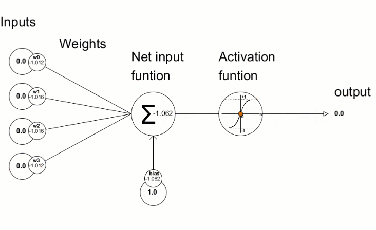

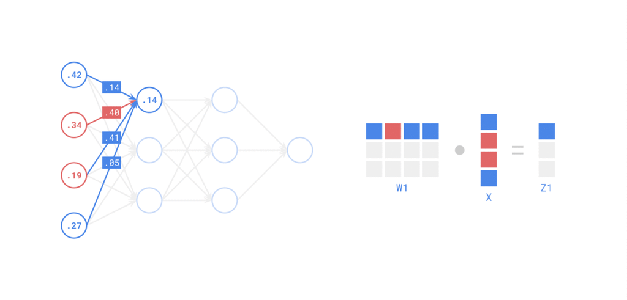

```python
# --- Activation Functions and their Derivatives ---
def sigmoid(x):
    return 1 / (1 + np.exp(-x))

def sigmoid_derivative(x):
    s = sigmoid(x)
    return s * (1 - s)

def relu(x):
    return np.maximum(0, x)

def relu_derivative(x):
    return (x > 0).astype(float)

def softmax(x):
    exp_x = np.exp(x - np.max(x, axis=-1, keepdims=True)) # Subtract max for numerical stability
    return exp_x / np.sum(exp_x, axis=-1, keepdims=True)

# --- Define Network Parameters (Manual for simplicity) ---
# Input layer (2 features) -> Hidden layer (3 neurons) -> Output layer (2 classes)
input_size = 2
hidden_size = 3
output_size = 2

# Initialize weights and biases (randomly, typically small values)
np.random.seed(42) # for reproducibility

# Weights from input to hidden layer
W1 = np.random.randn(input_size, hidden_size) * 0.01 # shape (2, 3)
b1 = np.zeros((1, hidden_size)) # shape (1, 3)

# Weights from hidden to output layer
W2 = np.random.randn(hidden_size, output_size) * 0.01 # shape (3, 2)
b2 = np.zeros((1, output_size)) # shape (1, 2)

print(f"W1 shape: {W1.shape}, b1 shape: {b1.shape}")
print(f"W2 shape: {W2.shape}, b2 shape: {b2.shape}")
```

```
W1 shape: (2, 3), b1 shape: (1, 3)
W2 shape: (3, 2), b2 shape: (1, 2)
```

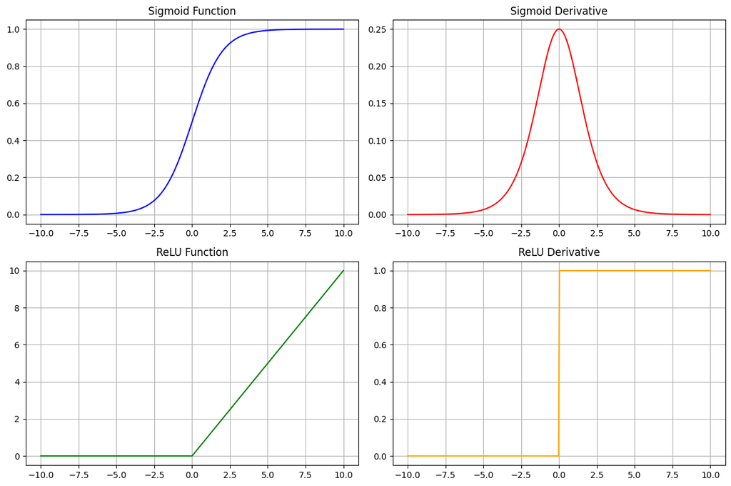

```python
# --- Visualization of Activation Functions ---
x_vals = np.linspace(-10, 10, 400)

fig, axs = plt.subplots(2, 2, figsize=(12, 8))

# Sigmoid
axs[0, 0].plot(x_vals, sigmoid(x_vals), label="Sigmoid", color='blue')
axs[0, 0].set_title("Sigmoid Function")
axs[0, 0].grid(True)

# Sigmoid Derivative
axs[0, 1].plot(x_vals, sigmoid_derivative(x_vals), label="Sigmoid Derivative", color='red')
axs[0, 1].set_title("Sigmoid Derivative")
axs[0, 1].grid(True)

# ReLU
axs[1, 0].plot(x_vals, relu(x_vals), label="ReLU", color='green')
axs[1, 0].set_title("ReLU Function")
axs[1, 0].grid(True)

# ReLU Derivative
axs[1, 1].plot(x_vals, relu_derivative(x_vals), label="ReLU Derivative", color='orange')
axs[1, 1].set_title("ReLU Derivative")
axs[1, 1].grid(True)

plt.tight_layout()
plt.show()
```

```python
# --- Forward Pass Implementation ---
def forward_pass(X, W1, b1, W2, b2):
    # Layer 1 (Hidden Layer)
    Z1 = np.dot(X, W1) + b1 # Linear combination
    A1 = sigmoid(Z1)        # Activation

    # Layer 2 (Output Layer)
    Z2 = np.dot(A1, W2) + b2 # Linear combination
    A2 = softmax(Z2)         # Activation (probabilities for output)

    # Store intermediate values needed for backpropagation
    cache = (X, Z1, A1, Z2, A2)
    return (A2, cache) # Explicitly return a tuple of two items

# Example Input (1 sample with 2 features)
X_sample = np.array([[0.5, 1.2]])
print(f"\nSample Input (X_sample):\n{X_sample}")

# Perform forward pass
output_probabilities, cache = forward_pass(X_sample, W1, b1, W2, b2)

print(f"\nInitial Output Probabilities (A2):\n{output_probabilities}")
print(f"Predicted class: {np.argmax(output_probabilities)}")

# Unpack cache for inspection
X_val, Z1_val, A1_val, Z2_val, A2_val = cache
print(f"\nZ1 (pre-activation hidden): {Z1_val}")
print(f"A1 (activated hidden): {A1_val}")
print(f"Z2 (pre-activation output): {Z2_val}")
```

```
Sample Input (X_sample):
[[0.5 1.2]]

Initial Output Probabilities (A2):
[[0.49976532 0.50023468]]
Predicted class: 1

Z1 (pre-activation hidden): [[ 0.02075993 -0.00350116  0.0004288 ]]
A1 (activated hidden): [[0.5051898  0.49912471 0.5001072 ]]
Z2 (pre-activation output): [[0.00331717 0.00425591]]
```

### **Discussion Point:**

- Trace the dimensions of the matrices (input, weights, biases) as they flow through the `forward_pass` function. How do the shapes align for matrix multiplication?
- What is the purpose of the `cache` variable? Why is it important to store these intermediate values?

### Part 2: Implementing Backpropagation from Scratch

This is the core of the lab. We will implement the backward pass to calculate gradients, which are then used to update weights and biases. We'll use a simple dataset and a very basic training loop.

**Tasks:**

```python
# --- Loss Function and its Derivative ---
def cross_entropy_loss(y_pred, y_true):
    # Ensure numerical stability
    y_pred = np.clip(y_pred, 1e-12, 1 - 1e-12)
    return -np.sum(y_true * np.log(y_pred)) / y_true.shape[0]

def cross_entropy_derivative(y_pred, y_true):
    return (y_pred - y_true) / y_true.shape[0] # Derivative for softmax + cross-entropy

# --- Backward Pass Implementation ---
def backward_pass(X, y_true, cache, W2):
    X_val, Z1_val, A1_val, Z2_val, A2_val = cache
    m = X.shape[0] # Number of samples

    # Output Layer Gradients
    # dZ2: Gradient of loss wrt Z2 (pre-activation output)
    # This specific derivative dL/dZ2 for softmax + cross-entropy simplifies to (A2 - y_true)
    dZ2 = cross_entropy_derivative(A2_val, y_true) # shape (m, output_size)

    # dW2: Gradient of loss wrt W2 (weights from hidden to output)
    dW2 = np.dot(A1_val.T, dZ2) # shape (hidden_size, output_size)
    # db2: Gradient of loss wrt b2 (bias for output layer)
    db2 = np.sum(dZ2, axis=0, keepdims=True) # shape (1, output_size)

    # Hidden Layer Gradients
    # dA1: Gradient of loss wrt A1 (activated hidden)
    dA1 = np.dot(dZ2, W2.T) # shape (m, hidden_size)

    # dZ1: Gradient of loss wrt Z1 (pre-activation hidden)
    # Apply derivative of activation function here
    dZ1 = dA1 * sigmoid_derivative(Z1_val) # shape (m, hidden_size)

    # dW1: Gradient of loss wrt W1 (weights from input to hidden)
    dW1 = np.dot(X_val.T, dZ1) # shape (input_size, hidden_size)
    # db1: Gradient of loss wrt b1 (bias for hidden layer)
    db1 = np.sum(dZ1, axis=0, keepdims=True) # shape (1, hidden_size)

    gradients = {"dW1": dW1, "db1": db1, "dW2": dW2, "db2": db2}
    return gradients
```

```python
# --- Generate a simple dataset for binary classification ---
# Using make_classification for a slightly more complex but still separable dataset
X_data, y_data = make_classification(n_samples=100, n_features=2, n_redundant=0, n_informative=2,
                                     n_clusters_per_class=1, random_state=42, n_classes=2)

# Scale features
scaler_bp = StandardScaler()
X_data_scaled = scaler_bp.fit_transform(X_data)

# One-hot encode target for 2 classes
y_data_oh = to_categorical(y_data, num_classes=2)

print(f"\nGenerated data shape: {X_data_scaled.shape}, Target one-hot shape: {y_data_oh.shape}")
```

```
Generated data shape: (100, 2), Target one-hot shape: (100, 2)
```

[output not shown]

[output cut: 4949 more lines]

[output not shown]

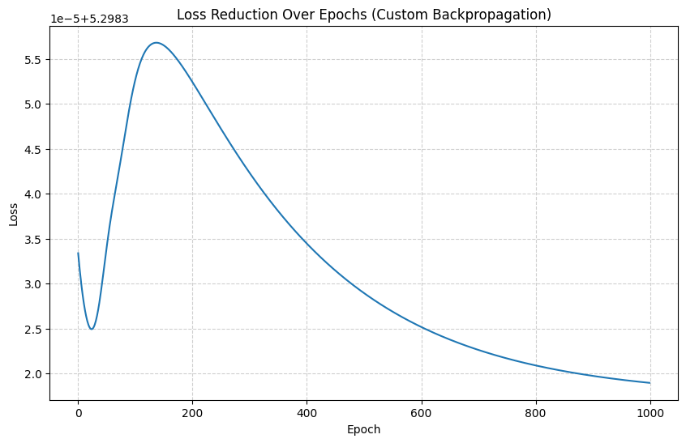

```python
# --- Training Loop with Backpropagation ---
epochs = 1000
learning_rate = 0.1
losses = []

# Re-initialize weights for training loop
np.random.seed(42)
W1_train = np.random.randn(input_size, hidden_size) * 0.01
b1_train = np.zeros((1, hidden_size))
W2_train = np.random.randn(hidden_size, output_size) * 0.01
b2_train = np.zeros((1, output_size))

print("\nStarting training with custom backpropagation...")
for epoch in range(epochs):
    # Forward Pass
    # Print shapes for debugging
    print(f"Epoch {epoch}: X_data_scaled shape: {X_data_scaled.shape}")
    print(f"Epoch {epoch}: W1_train shape: {W1_train.shape}")
    print(f"Epoch {epoch}: b1_train shape: {b1_train.shape}")
    print(f"Epoch {epoch}: W2_train shape: {W2_train.shape}")
    print(f"Epoch {epoch}: b2_train shape: {b2_train.shape}")

    y_pred, cache = forward_pass(X_data_scaled, W1_train, b1_train, W2_train, b2_train)

    # Calculate Loss
    loss = cross_entropy_loss(y_pred, y_data_oh)
    losses.append(loss)

    # Backward Pass (Calculate Gradients)
    gradients = backward_pass(X_data_scaled, y_data_oh, cache, W2_train)
    dW1, db1, dW2, db2 = gradients["dW1"], gradients["db1"], gradients["dW2"], gradients["db2"]

    # Update Weights and Biases
    W1_train -= learning_rate * dW1
    b1_train -= learning_rate * db1
    W2_train -= learning_rate * dW2
    b2_train -= learning_rate * db2

    if epoch % 100 == 0:
        print(f"Epoch {epoch}/{epochs}, Loss: {loss:.4f}")

print("\nTraining complete.")
print(f"Final Loss: {losses[-1]:.4f}")

# Plotting the loss over epochs
plt.figure(figsize=(10, 6))
plt.plot(losses)
plt.title('Loss Reduction Over Epochs (Custom Backpropagation)')
plt.xlabel('Epoch')
plt.ylabel('Loss')
plt.grid(True, linestyle='--', alpha=0.6)
plt.show()
```

```
Final Accuracy of Custom Model: 0.5000
```

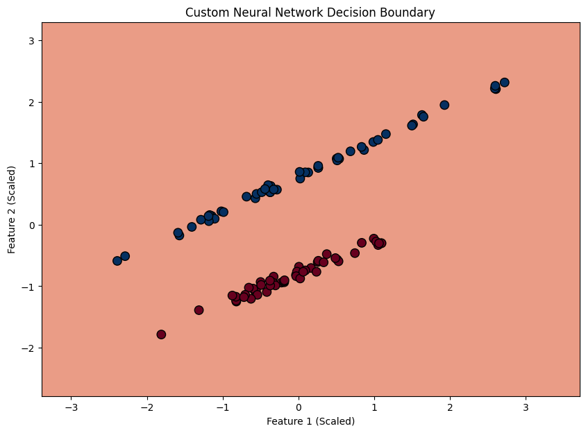

```python
# --- Evaluate the trained model (custom) ---
final_pred_proba, _ = forward_pass(X_data_scaled, W1_train, b1_train, W2_train, b2_train)
final_pred_labels = np.argmax(final_pred_proba, axis=1)
accuracy = accuracy_score(y_data, final_pred_labels)
print(f"\nFinal Accuracy of Custom Model: {accuracy:.4f}")

# Plot decision boundary (optional, for 2D data)
plt.figure(figsize=(10, 7))
h = .02  # step size in the mesh
x_min, x_max = X_data_scaled[:, 0].min() - 1, X_data_scaled[:, 0].max() + 1
y_min, y_max = X_data_scaled[:, 1].min() - 1, X_data_scaled[:, 1].max() + 1
xx, yy = np.meshgrid(np.arange(x_min, x_max, h),
                     np.arange(y_min, y_max, h))

Z = np.argmax(forward_pass(np.c_[xx.ravel(), yy.ravel()], W1_train, b1_train, W2_train, b2_train)[0], axis=1)
Z = Z.reshape(xx.shape)
plt.contourf(xx, yy, Z, cmap=plt.cm.RdBu, alpha=0.8)
plt.scatter(X_data_scaled[:, 0], X_data_scaled[:, 1], c=y_data, cmap=plt.cm.RdBu, edgecolor='k', s=80)
plt.title('Custom Neural Network Decision Boundary')
plt.xlabel('Feature 1 (Scaled)')
plt.ylabel('Feature 2 (Scaled)')
plt.show()
```

### **Discussion Points:**

- Explain the role of the chain rule in the `backward_pass` function, especially when calculating `dZ1`.
- What does the loss plot tell you about the training process? If the loss wasn't decreasing, what might be wrong?
- How does the `learning_rate` impact the training process? What happens if it's too high or too low?

### Part 3: Backpropagation in Practice (Using TensorFlow/Keras)

While implementing backpropagation from scratch provides deep understanding, in practice, deep learning frameworks like TensorFlow/Keras automate this complex process. They use highly optimized C++/CUDA implementations of backpropagation, often with automatic differentiation.

**Tasks:**

- Build the same network architecture (2 input -> 3 hidden -> 2 output) using Keras's Sequential API.
- Train the Keras model on the same `X_data_scaled` and `y_data_oh`.
- Compare the performance and ease of implementation to the "from scratch" version.

```python
# Define the Keras model
keras_model = Sequential([
    Dense(units=3, activation='sigmoid', input_shape=(input_size,)), # Hidden layer
    Dense(units=output_size, activation='softmax')                     # Output layer
])

# Compile the model
keras_model.compile(optimizer='adam',
                    loss='categorical_crossentropy',
                    metrics=['accuracy'])

keras_model.summary()
```

```
Model: "sequential"
```

```
┏━━━━━━━━━━━━━━━━━━━━━━━━━━━━━━━━━┳━━━━━━━━━━━━━━━━━━━━━━━━┳━━━━━━━━━━━━━━━┓
┃ Layer (type)                    ┃ Output Shape           ┃       Param # ┃
┡━━━━━━━━━━━━━━━━━━━━━━━━━━━━━━━━━╇━━━━━━━━━━━━━━━━━━━━━━━━╇━━━━━━━━━━━━━━━┩
│ dense (Dense)                   │ (None, 3)              │             9 │
├─────────────────────────────────┼────────────────────────┼───────────────┤
│ dense_1 (Dense)                 │ (None, 2)              │             8 │
└─────────────────────────────────┴────────────────────────┴───────────────┘
```

```
 Total params: 17 (68.00 B)
```

```
 Trainable params: 17 (68.00 B)
```

```
 Non-trainable params: 0 (0.00 B)
```

```python
# Train the Keras model
print("\nStarting training with Keras (using built-in backpropagation)...")
history_keras = keras_model.fit(X_data_scaled, y_data_oh,
                                epochs=1000,
                                batch_size=32, # Keras often uses larger batch sizes by default
                                verbose=0) # Set verbose to 0 to suppress per-epoch output

print("\nKeras training complete.")
print(f"Final Keras Loss: {history_keras.history['loss'][-1]:.4f}")
```

```
Starting training with Keras (using built-in backpropagation)...

Keras training complete.
Final Keras Loss: 0.0132
```

```
Final Keras Model Accuracy: 1.0000
```

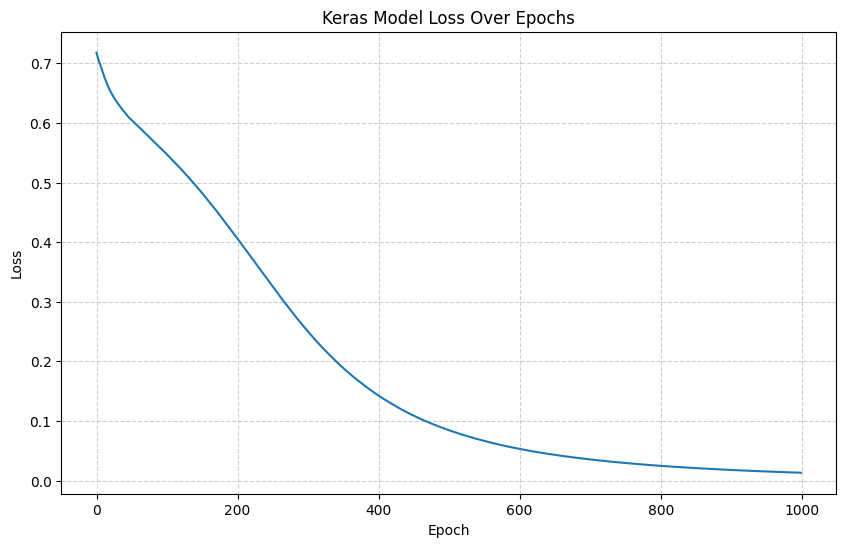

```
3394/3394 ━━━━━━━━━━━━━━━━━━━━ 6s 2ms/step
```

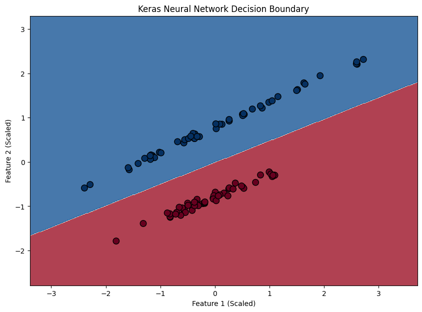

```python
# Evaluate the Keras model
loss_keras, accuracy_keras = keras_model.evaluate(X_data_scaled, y_data_oh, verbose=0)
print(f"Final Keras Model Accuracy: {accuracy_keras:.4f}")

# Plot Keras training loss
plt.figure(figsize=(10, 6))
plt.plot(history_keras.history['loss'])
plt.title('Keras Model Loss Over Epochs')
plt.xlabel('Epoch')
plt.ylabel('Loss')
plt.grid(True, linestyle='--', alpha=0.6)
plt.show()

# Plot Keras decision boundary
plt.figure(figsize=(10, 7))
h = .02
x_min, x_max = X_data_scaled[:, 0].min() - 1, X_data_scaled[:, 0].max() + 1
y_min, y_max = X_data_scaled[:, 1].min() - 1, X_data_scaled[:, 1].max() + 1
xx, yy = np.meshgrid(np.arange(x_min, x_max, h),
                     np.arange(y_min, y_max, h))

Z_keras = np.argmax(keras_model.predict(np.c_[xx.ravel(), yy.ravel()]), axis=1)
Z_keras = Z_keras.reshape(xx.shape)
plt.contourf(xx, yy, Z_keras, cmap=plt.cm.RdBu, alpha=0.8)
plt.scatter(X_data_scaled[:, 0], X_data_scaled[:, 1], c=y_data, cmap=plt.cm.RdBu, edgecolor='k', s=80)
plt.title('Keras Neural Network Decision Boundary')
plt.xlabel('Feature 1 (Scaled)')
plt.ylabel('Feature 2 (Scaled)')
plt.show()
```

### **Discussion Points:**

- Compare the final loss and accuracy of your custom NumPy implementation with the Keras implementation. What factors might account for any differences?
- How does Keras simplify the process of implementing and training a neural network compared to doing it from scratch? What specific aspects does it abstract away?

### Part 4: Advanced Topics & Discussion:

This section is for broader discussion and conceptual understanding, extending beyond direct coding.

**Discussion Topics:**

- **Vanishing/Exploding Gradients:** What are these problems, why do they occur in deep networks, and what techniques are used to mitigate them?
- **Computational Graph:** Explain the concept of a computational graph in the context of backpropagation.
- **Automatic Differentiation:** How do modern deep learning frameworks (like TensorFlow/PyTorch) handle differentiation, making backpropagation seamless for users?
- **Beyond Gradient Descent:** Briefly discuss how more advanced optimizers (e.g., Adam, RMSprop) improve upon basic Gradient Descent in the context of backpropagation.
- **Limitations of Backpropagation:** Are there scenarios where backpropagation might not be suitable or faces inherent challenges?
- **Vanishing/Exploding Gradients:**
  - **Vanishing Gradients:** This occurs in deep neural networks when the gradients become extremely small as they propagate backward through many layers (especially with activation functions like Sigmoid or Tanh, whose derivatives are small). As gradients shrink, the updates to the weights and biases in earlier layers become negligible, making those layers learn very slowly or stop learning altogether.
  - **Exploding Gradients:** Conversely, exploding gradients happen when gradients become excessively large during backpropagation. This leads to very large weight updates, causing the training process to become unstable, oscillating wildly or even diverging.
  - **Why they occur:** Primarily due to repeated multiplication of gradients through many layers. If the values of the derivatives are consistently less than 1 (vanishing) or consistently greater than 1 (exploding), the product accumulates to a very small or very large number, respectively.
  - **Mitigation Techniques:**
    - **Vanishing:**
      - **ReLU-family Activation Functions:** ReLU, Leaky ReLU, ELU, Swish have derivatives that are either 0 or 1 (or a small constant), preventing the product from shrinking too rapidly.
      - **Proper Weight Initialization:** Techniques like He initialization (for ReLU) or Xavier/Glorot initialization (for Sigmoid/Tanh) ensure that initial weights are in a range that prevents activations from being pushed to the extremes.
      - **Batch Normalization:** Normalizes the inputs of each layer, preventing small changes in previous layers from amplifying into large changes in subsequent layers, thus stabilizing gradients.
      - **Residual Connections (ResNets):** Allow gradients to bypass layers directly, helping them flow more easily through very deep networks.
    - **Exploding:**
      - **Gradient Clipping:** If the gradient norm exceeds a certain threshold, it is rescaled back down to that threshold. This prevents individual large gradients from disrupting the learning process.
      - **Smaller Learning Rates:** A straightforward approach, though it can slow down convergence.
- **Computational Graph:**
  - A computational graph (or dataflow graph) is a way to represent mathematical operations as a graph. In the context of neural networks and backpropagation, each node in the graph represents an operation (e.g., matrix multiplication, addition, activation function), and the edges represent the flow of data (tensors).
  - **How it relates to Backpropagation:** During the forward pass, data flows forward through this graph, computing intermediate results and the final output. During backpropagation, the gradients are calculated by traversing this graph in reverse (backward pass), applying the chain rule at each node to compute the partial derivative of the loss with respect to that node's inputs and parameters. Modern deep learning frameworks construct and manage this graph automatically.
- **Automatic Differentiation:**
  - Automatic differentiation (AutoDiff) is a set of techniques used by deep learning frameworks (like TensorFlow's `tf.GradientTape` or PyTorch's autograd) to efficiently and accurately compute derivatives of complex functions. It's not symbolic differentiation (which computes formulas) or numerical differentiation (which approximates derivatives using finite differences).
  - **How it works:** AutoDiff leverages the chain rule. It records the sequence of operations performed during the forward pass. Then, to compute gradients, it traverses this recorded "tape" or computational graph backward, applying the chain rule step by step to propagate gradients. This automation is what makes it feasible for users to build and train incredibly complex neural networks without manually deriving gradients for every single weight and bias.
- **Beyond Gradient Descent:**
  - Basic Gradient Descent (GD) updates weights using the gradient of the entire dataset. Stochastic Gradient Descent (SGD) uses one sample at a time, and Mini-Batch Gradient Descent uses a small batch. While fundamental, these can be slow or get stuck in local minima.
  - **Advanced Optimizers (e.g., Adam, RMSprop, Adagrad):** These optimizers build upon GD by incorporating concepts like **momentum** (which helps accelerate GD in the relevant direction and dampens oscillations) and **adaptive learning rates** (which adjust the learning rate for each parameter individually based on past gradients).
  - **How they improve:** They help in:
    - **Faster Convergence:** By taking larger steps in flatter regions and smaller steps near minima.
    - **Better Generalization:** Often find better minima that generalize well to unseen data.
    - **Handling Sparsity:** Can perform better with sparse data by adapting learning rates.
    - **Robustness:** Less sensitive to the initial learning rate choice compared to vanilla GD.
  - **Example (Adam):** Adam combines the advantages of RMSprop (adaptive learning rates based on squared gradients) and momentum (adaptive learning rates based on past gradients). It's often the default choice in many deep learning applications due to its efficiency and good performance.
- **Limitations of Backpropagation:**
  - **Vanishing/Exploding Gradients:** As discussed, this is a major challenge for very deep networks, though techniques exist to mitigate it.
  - **Local Minima and Saddle Points:** Gradient-based optimization can get stuck in local minima or saddle points (where the gradient is zero, but it's not a true minimum), preventing the model from reaching the global optimum. Advanced optimizers and good initialization help but don't entirely eliminate this.
  - **Computational Cost:** For very large models and datasets, backpropagation (and the overall training process) is computationally intensive, requiring significant hardware resources (GPUs/TPUs).
  - **Requires Differentiable Functions:** Backpropagation relies on the differentiability of activation functions and loss functions. Non-differentiable operations cannot be directly used.
  - **Black Box Nature:** While backpropagation allows training, it doesn't inherently provide interpretability into *why* the network makes certain decisions. The weights and biases themselves don't have direct human-understandable meaning.
  - **Data Hunger:** Deep learning models trained with backpropagation often require massive amounts of labeled data to perform well, which can be expensive or impossible to acquire for certain domains.

Prepared By

**Md. Atikuzzaman**  
Lecturer  
Department of Computer Science and Engineering  
Green University of Bangladesh  
Email: atik@cse.green.edu.bd